# Classification results, Stat 302 Fall 2017

**Group members**: `Chongyi Xu, Yichao Wang, Mingsu Hou, Xiaohan Hu, Wenqin Du, Xiaofan Xia`

**Dataset**: `NYC parole hearings`

## Description of your overall results

- The results we got is following:

[output not shown]

- Conclusion: Through all of the methods we have used, although there are some methods performing really well in computing recall or precision, the accuracies are not good enough to say that our data is relevant to the varibales we have picked. The problems could be
  - The varibales we have picked are not useful
  - The data itself is hard to model
  - Need some more variables to check
  - …

## Methods for classification

Show the results from the six classification methods.

### Logistic regression

```r
options(warn=-1)
library(dplyr)
```

```r
library("stringr")
library(ggplot2)
library(class)
library(caret)
require(e1071)
library(pROC)
library(ROCR)
dat <- read.csv("paroledat.csv", stringsAsFactors = FALSE)
dat <- dat %>% dplyr::select(sex, "race"=race...ethnicity, "crime1" = crime.1...class, "decision" = interview.decision, "min" = aggregated.minimum.sentence, "max" = aggregated.maximum.sentence) %>% filter(decision != "*", decision != "**********", crime1 != "")
dat$min <- str_sub(dat$min,1,2)
dat$max <- str_sub(dat$max,1,2)
dat$min <- as.numeric(dat$min)
dat$max <- as.numeric(dat$max)
# Note: 0 for not denied and 1 for denied
dat$decision[which(dat$decision != "DENIED")] <- 1
dat$decision[which(dat$decision == "DENIED")] <- 0
train <- dat[1:30000,]
test <- dat[30001:39890,]
model <- glm(as.numeric(decision)~sex+race+crime1+min+max, family='binomial', data=train)

# Evaluation
anova(model, test="Chisq")
```

```
## Analysis of Deviance Table
##
## Model: binomial, link: logit
##
## Response: as.numeric(decision)
##
## Terms added sequentially (first to last)
##
##
##        Df Deviance Resid. Df Resid. Dev  Pr(>Chi)
## NULL                   28393      38662
## sex     2   280.36     28391      38381 < 2.2e-16 ***
## race    6   164.93     28385      38216 < 2.2e-16 ***
## crime1  4   720.01     28381      37496 < 2.2e-16 ***
## min     1   415.40     28380      37081 < 2.2e-16 ***
## max     1    73.30     28379      37008 < 2.2e-16 ***
## ---
## Signif. codes:  0 '***' 0.001 '**' 0.01 '*' 0.05 '.' 0.1 ' ' 1
```

```r
pred <- predict(model, newdata=test)
pred <- ifelse(pred > 0.5, 1, 0)

confusionMatrix(data=pred, test$decision, mode='prec_recall')
```

```
## Confusion Matrix and Statistics
##
##           Reference
## Prediction    0    1
##          0 5367 3800
##          1  114  266
##
##                Accuracy : 0.59
##                  95% CI : (0.5801, 0.5999)
##     No Information Rate : 0.5741
##     P-Value [Acc > NIR] : 0.0008434
##
##                   Kappa : 0.0505
##  Mcnemar's Test P-Value : < 2.2e-16
##
##               Precision : 0.5855
##                  Recall : 0.9792
##                      F1 : 0.7328
##              Prevalence : 0.5741
##          Detection Rate : 0.5622
##    Detection Prevalence : 0.9602
##       Balanced Accuracy : 0.5223
##
##        'Positive' Class : 0
##
```

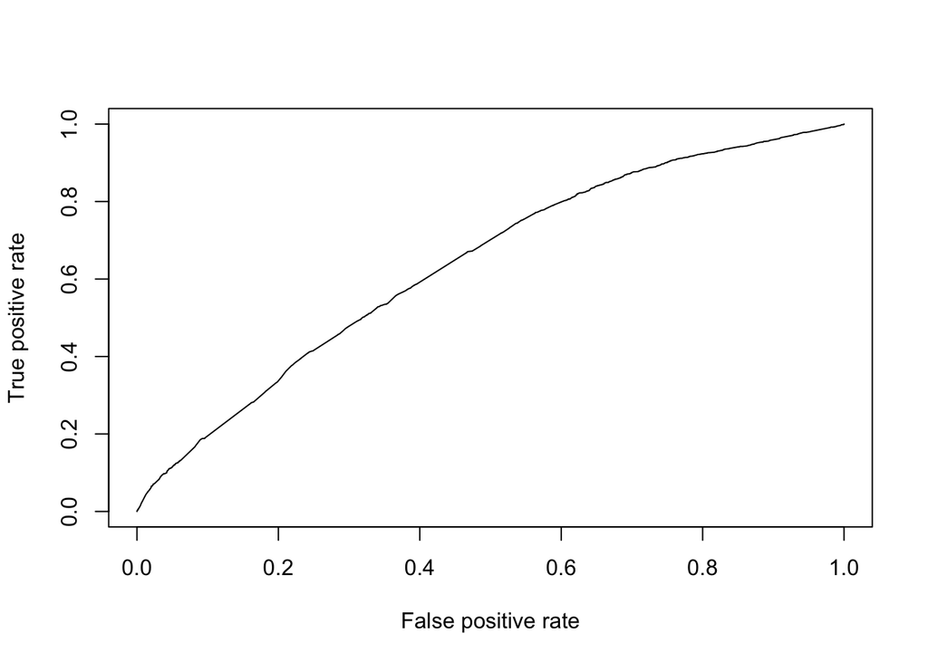

```r
# ROC
prob <- predict(model, newdata=test)
pred <- prediction(prob, test$decision)
perf <- performance(pred, measure = "tpr", x.measure = "fpr")
plot(perf)
```

### Discriminant analysis (linear and quadratic)

- Because the data is not continuous, I can not get proper result from discriminant analysis. The result of prediction is numerical so it is not suitable to get the confusion matrix.

```r
dat <- read.csv("paroledat.csv", stringsAsFactors = FALSE)
dat <- dat %>% dplyr::select(sex, "race"=race...ethnicity, "crime1" = crime.1...class, "decision" = interview.decision, "min" = aggregated.minimum.sentence, "max" = aggregated.maximum.sentence) %>% filter(decision != "*", decision != "**********", crime1 != "")
dat$min <- str_sub(dat$min,1,2)
dat$max <- str_sub(dat$max,1,2)
dat$min <- as.numeric(dat$min)
dat$max <- as.numeric(dat$max)
dat$decision[which(dat$decision != "DENIED")] <- "NOTD"
dat$decision[which(dat$decision == "DENIED")] <- "D"

dat$crime1[which(dat$crime1 =='A')]<-0
dat$crime1[which(dat$crime1 =='B')]<-1
dat$crime1[which(dat$crime1 =='C')]<-2
dat$crime1[which(dat$crime1 =='D')]<-3
dat$crime1[which(dat$crime1 =='E')]<-4

dat$race[which(dat$race =='WHITE')]<-0
dat$race[which(dat$race =='BLACK')]<-1
dat$race[which(dat$race =='HISPANIC')]<-2
dat$race[which(dat$race =='AMER IND/ALSK')]<-3
dat$race[which(dat$race =='ASIAN/PACIFIC')]<-4
dat$race[which(dat$race =='UNKNOWN')]<-5
dat$race[which(dat$race =='OTHER')]<-6

dat$sex[which(dat$sex =='MALE')]<-0
dat$sex[which(dat$sex =='FEMALE')]<-1

dat$race <- as.numeric(dat$race)
dat$sex <- as.numeric(dat$sex)
dat$crime1 <- as.numeric(dat$crime1)
dat$min <- as.numeric(dat$min)
dat$max <- as.numeric(dat$max)
dat$decision <- as.factor(dat$decision)

new <-na.omit(dat)
library(MASS)
lda_model <- lda(decision~.,data = new)
lda_model
```

```
## Call:
## lda(decision ~ ., data = new)
##
## Prior probabilities of groups:
##        D     NOTD
## 0.577184 0.422816
##
## Group means:
##             sex      race   crime1      min      max
## D    0.04569573 1.0204007 2.505763 5.423246 23.11605
## NOTD 0.09815798 0.9820169 2.925944 2.960287 11.06550
##
## Coefficients of linear discriminants:
##                LD1
## sex     1.60733999
## race    0.02712880
## crime1  0.11505494
## min    -0.07519477
## max    -0.01085087
```

```r
lda_pred<- predict(lda_model,dat[,-4])
```

### Classification trees

```r
dat <- read.csv("paroledat.csv", stringsAsFactors = FALSE)
dat <- dat %>% dplyr::select(sex, "race"=race...ethnicity, "crime1" = crime.1...class, "decision" = interview.decision, "min" = aggregated.minimum.sentence, "max" = aggregated.maximum.sentence) %>% filter(decision != "*", decision != "**********", crime1 != "")
dat$min <- str_sub(dat$min,1,2)
dat$max <- str_sub(dat$max,1,2)
dat$min <- as.numeric(dat$min)
dat$max <- as.numeric(dat$max)
dat$decision[which(dat$decision != "DENIED")] <- "NOTD"
dat$decision[which(dat$decision == "DENIED")] <- "D"

library("rpart")
library("rpart.plot")
fit <- rpart(decision~sex+race+crime1+min+max, method="class", data=dat)
printcp(fit)
```

```
##
## Classification tree:
## rpart(formula = decision ~ sex + race + crime1 + min + max, data = dat,
##     method = "class")
##
## Variables actually used in tree construction:
## [1] max sex
##
## Root node error: 17812/39890 = 0.44653
##
## n= 39890
##
##         CP nsplit rel error  xerror      xstd
## 1 0.017881      0   1.00000 1.00000 0.0055743
## 2 0.010000      2   0.96424 0.96424 0.0055521
```

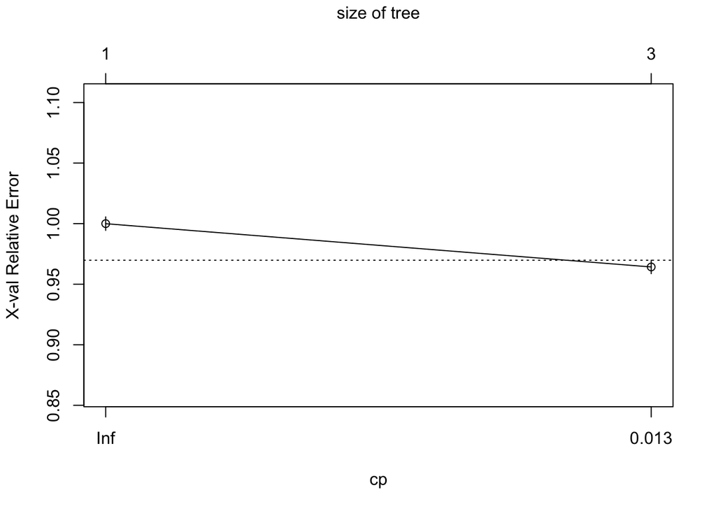

```r
plotcp(fit)
```

```r
summary(fit)
```

```
## Call:
## rpart(formula = decision ~ sex + race + crime1 + min + max, data = dat,
##     method = "class")
##   n= 39890
##
##          CP nsplit rel error    xerror        xstd
## 1 0.0178812      0 1.0000000 1.0000000 0.005574315
## 2 0.0100000      2 0.9642376 0.9642376 0.005552135
##
## Variable importance
##    max    min crime1    sex
##     40     32     21      7
##
## Node number 1: 39890 observations,    complexity param=0.0178812
##   predicted class=D     expected loss=0.446528  P(node) =1
##     class counts: 22078 17812
##    probabilities: 0.553 0.447
##   left son=2 (10675 obs) right son=3 (29215 obs)
##   Primary splits:
##       max    < 9.5 to the right, improve=722.59790, (1949 missing)
##       min    < 2.5 to the right, improve=288.18800, (0 missing)
##       sex    splits as  RLL,     improve=160.79020, (0 missing)
##       crime1 splits as  LLLRR,   improve=149.78830, (0 missing)
##       race   splits as  LRLRRLR, improve= 64.05872, (0 missing)
##   Surrogate splits:
##       min    < 3.5 to the right, agree=0.954, adj=0.802, (1949 split)
##       crime1 splits as  LLRRR,   agree=0.889, adj=0.521, (0 split)
##       race   splits as  RRRRRLR, agree=0.769, adj=0.003, (0 split)
##
## Node number 2: 10675 observations
##   predicted class=D     expected loss=0.3618735  P(node) =0.2676109
##     class counts:  6812  3863
##    probabilities: 0.638 0.362
##
## Node number 3: 29215 observations,    complexity param=0.0178812
##   predicted class=D     expected loss=0.4774602  P(node) =0.7323891
##     class counts: 15266 13949
##    probabilities: 0.523 0.477
##   left son=6 (26880 obs) right son=7 (2335 obs)
##   Primary splits:
##       sex    splits as  RLL,     improve=128.22500, (0 missing)
##       min    < 2.5 to the right, improve=107.68530, (0 missing)
##       race   splits as  LRLLRRR, improve= 59.92718, (0 missing)
##       max    < 4.5 to the right, improve= 51.43745, (77 missing)
##       crime1 splits as  RRLRR,   improve= 48.18520, (0 missing)
##
## Node number 6: 26880 observations
##   predicted class=D     expected loss=0.4636533  P(node) =0.6738531
##     class counts: 14417 12463
##    probabilities: 0.536 0.464
##
## Node number 7: 2335 observations
##   predicted class=NOTD  expected loss=0.3635974  P(node) =0.05853597
##     class counts:   849  1486
##    probabilities: 0.364 0.636
```

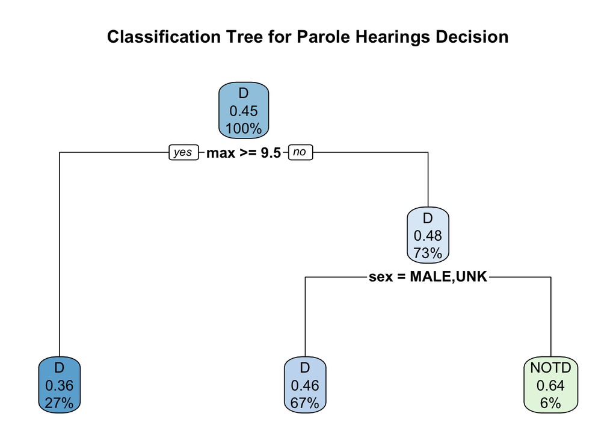

```r
rpart.plot(fit, uniform=TRUE, main="Classification Tree for Parole Hearings Decision")
```

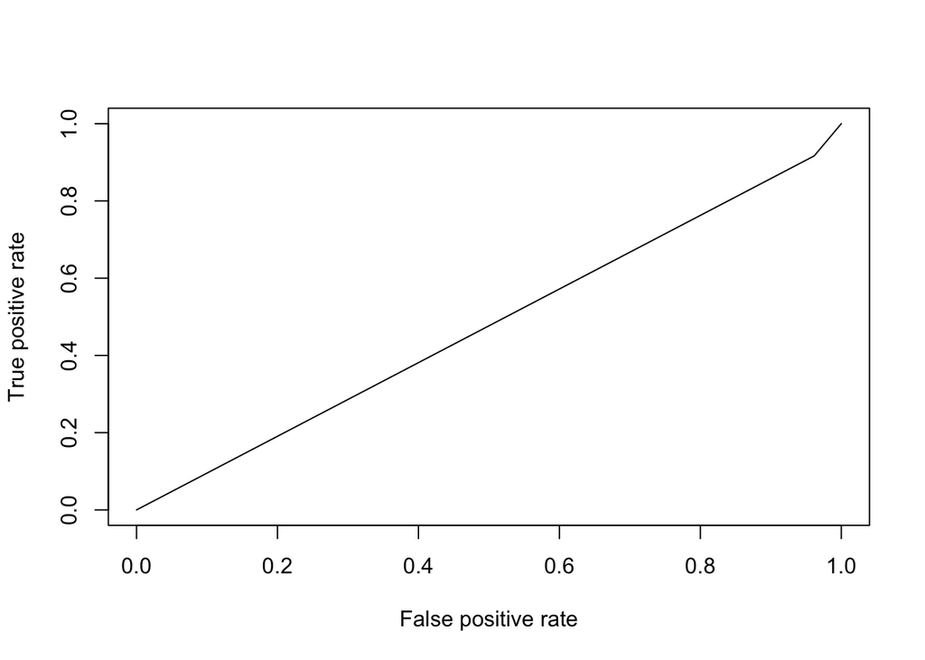

```r
post(fit, title = "Classification Tree for Parole Hearings Decision")
dat$race<- as.factor(dat$race)
dat$crime1<- as.factor(dat$crime1)
dat$sex <- as.factor(dat$sex)
dat$decision <- as.factor(dat$decision)

pred<-predict(fit,dat, type='prob')
pred[which(pred[,1]>0.5)] <- 1
pred[which(pred[,1]<0.5)] <- 0
pred<- pred[,-2]
pred<-prediction(pred,dat$decision)
roc<-performance(pred,"tpr","fpr")
plot(roc)
```

### Support vector machines

- We do not distinguish the test and training data using SVM method.
- We can get the classification result from the table above and then we can calculate the value of accuracy, precision and recall. The values are 0.5975394, 0.9413137 and 0.595802. The result of precision is much better than logistic regression but the result of recall is worse.
- From the ROC curve, we think the result of SVM method is not very good and this may be a result of the data we choose does not have enough information for us to use this method.

```r
# We often use SVM to do classificationif the boundary between classes non-linear class
# boundaries. The method of SVM is to map the data into a new space and transform them
# into linearly separable data in the new space.

dat <- read.csv("paroledat.csv", stringsAsFactors = FALSE)
dat <- dat %>% dplyr::select(sex, "race"=race...ethnicity, "crime1" = crime.1...class, "decision" = interview.decision, "min" = aggregated.minimum.sentence, "max" = aggregated.maximum.sentence) %>% filter(decision != "*", decision != "**********", crime1 != "")
dat$min <- str_sub(dat$min,1,2)
dat$max <- str_sub(dat$max,1,2)
dat$min <- as.numeric(dat$min)
dat$max <- as.numeric(dat$max)
dat$decision[which(dat$decision != "DENIED")] <- "NOTD"
dat$decision[which(dat$decision == "DENIED")] <- "D"

dat$crime1[which(dat$crime1 =='A')]<-0
dat$crime1[which(dat$crime1 =='B')]<-1
dat$crime1[which(dat$crime1 =='C')]<-2
dat$crime1[which(dat$crime1 =='D')]<-3
dat$crime1[which(dat$crime1 =='E')]<-4

dat$race[which(dat$race =='WHITE')]<-0
dat$race[which(dat$race =='BLACK')]<-1
dat$race[which(dat$race =='HISPANIC')]<-2
dat$race[which(dat$race =='AMER IND/ALSK')]<-3
dat$race[which(dat$race =='ASIAN/PACIFIC')]<-4
dat$race[which(dat$race =='UNKNOWN')]<-5
dat$race[which(dat$race =='OTHER')]<-6

dat$sex[which(dat$sex =='MALE')]<-0
dat$sex[which(dat$sex =='FEMALE')]<-1

dat$race <- as.numeric(dat$race)
dat$sex <- as.numeric(dat$sex)
dat$crime1 <- as.numeric(dat$crime1)
dat$min <- as.numeric(dat$min)
dat$max <- as.numeric(dat$max)
dat$decision <- as.factor(dat$decision)

new <-na.omit(dat)



dat_svm_model <- svm(decision ~., probability = TRUE , data = dat)
dat_svm_model
```

```
##
## Call:
## svm(formula = decision ~ ., data = dat, probability = TRUE)
##
##
## Parameters:
##    SVM-Type:  C-classification
##  SVM-Kernel:  radial
##        cost:  1
##       gamma:  0.2
##
## Number of Support Vectors:  30932
```

```r
dat_svm_model_pred <- predict(dat_svm_model, dat[,-4])
prediction <- predict(dat_svm_model, probability = TRUE, new[,-4])
c <- attr(prediction, "probabilities")

dat_table <- table(pred = dat_svm_model_pred,true = new[,4])
dat_table
```

```
##       true
## pred       D  NOTD
##   D    20579 13961
##   NOTD  1283  2054
```

```r
# We can get the classification result from the table above and then we can calculate the
# value of accuracy, precision and recall. The values are  0.5975394, 0.9413137 and 0.595802.

accuracy <- sum(diag(dat_table))/sum(dat_table)
accuracy
```

```
## [1] 0.5975394
```

```r
precision <- dat_table[1, 1]/sum(dat_table[, 1])
precision
```

```
## [1] 0.9413137
```

```r
recall <- dat_table[1, 1]/sum(dat_table[1,])
recall
```

```
## [1] 0.595802
```

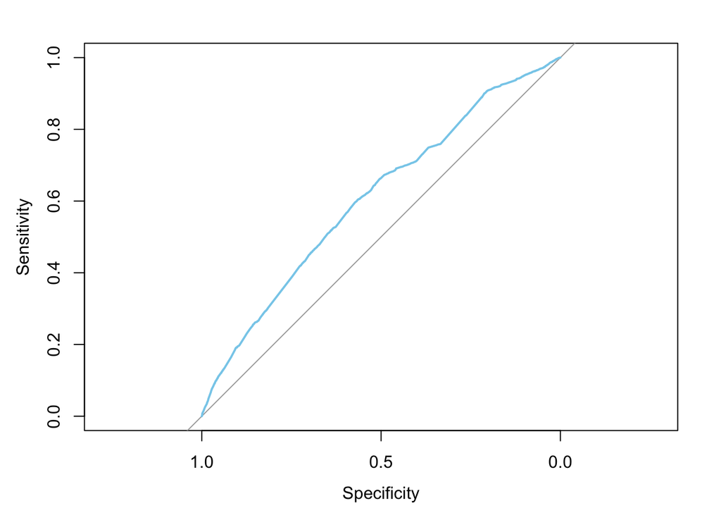

```r
roc <- roc(new[,4], c[, 1])
plot(roc, col = "skyblue")
```

### Naive Bayes

- Naive Bayes is not very useful for this dataset since accuracy is only 0.55.

```
## Confusion Matrix and Statistics
##
##
## pred      D NOTD
##   D    2342 1300
##   NOTD 3140 3108
##
##                Accuracy : 0.5511
##                  95% CI : (0.5412, 0.5609)
##     No Information Rate : 0.5543
##     P-Value [Acc > NIR] : 0.7446
##
##                   Kappa : 0.1271
##  Mcnemar's Test P-Value : <2e-16
##
##               Precision : 0.6431
##                  Recall : 0.4272
##                      F1 : 0.5134
##              Prevalence : 0.5543
##          Detection Rate : 0.2368
##    Detection Prevalence : 0.3683
##       Balanced Accuracy : 0.5661
##
##        'Positive' Class : D
##
```

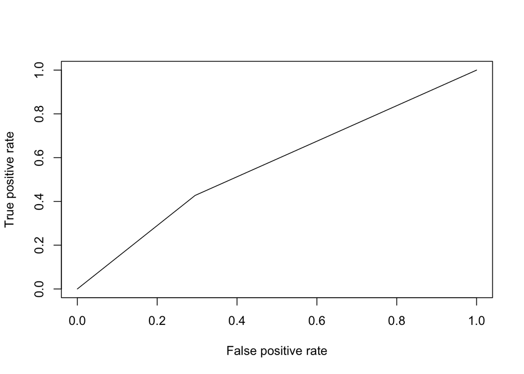